# Biotin report

# 2. Distribution across cell types

**`biotin_by_celltype_violin.png`**

Biotin by broad cell type, split by sample. Monocytes are the clear outlier, with pro-monocytes and cDC behind them; Pro-B, Pre-B and late erythroid sit lowest. The ordering is the same in normal-02, normal-CD34-01 and WEI21_26-17_NK, so it tracks cell identity rather than sample or disease state.

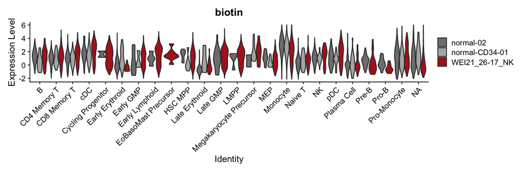

**`3c_glyco_by_fine_celltype_violin.pdf`**

The same picture at the fine cell type level, from step 02.

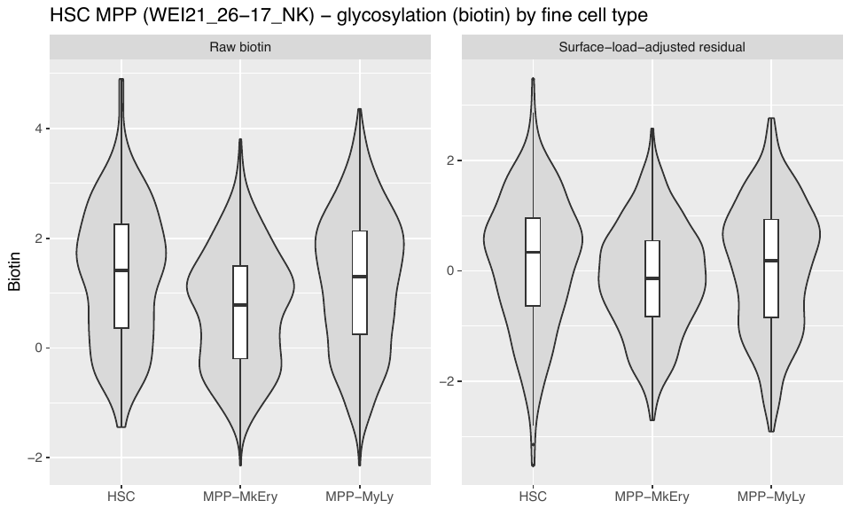

# 3. Biotin-high versus biotin-low in HSC/MPP

Step 02 takes the HSC/MPP compartment, splits it on CITE_DSB biotin, and asks what else differs. Everything in this section is one sample, `WEI21_26-17_NK`.

**`5a_biotin_group_umap_projected.pdf`**

The two groups on the projected UMAP.

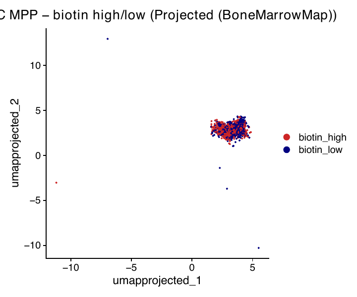

**`5b_biotin_value_umap_projected.pdf`**

Biotin as a continuous value on the same layout - the split is a threshold on this.

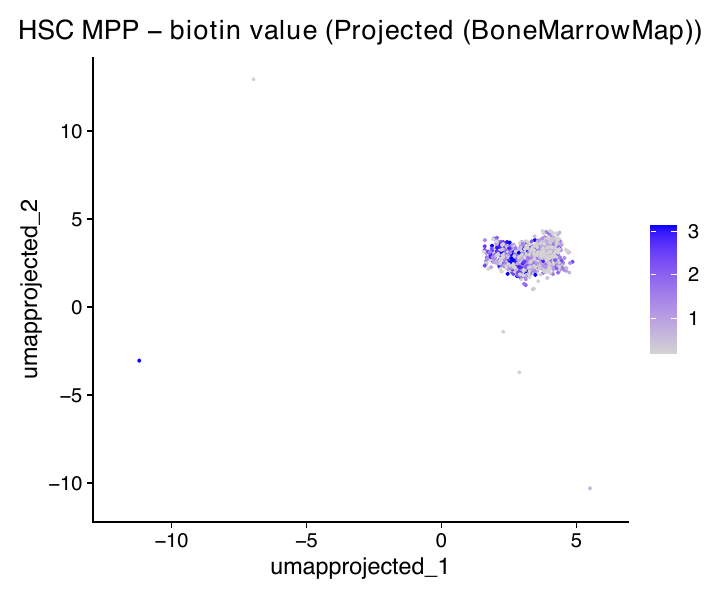

## RNA

**`2_pseudobulk_deseq2_volcano_biotin_high_vs_low.pdf`**

Pseudobulk DESeq2, biotin-high against biotin-low.

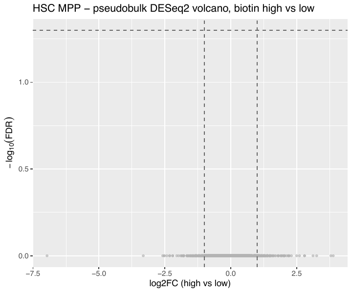

**`2_pseudobulk_edgeR_volcano_biotin_high_vs_low.pdf`**

The same contrast under edgeR - shown alongside because with one sample the choice of method matters more than usual.

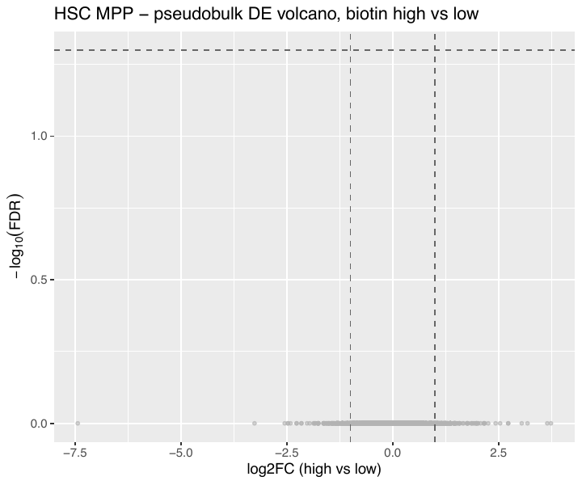

**`1b_fgsea_hallmark_biotin_high_vs_low.pdf`**

fgsea over MSigDB Hallmark, on the FindMarkers ranking.

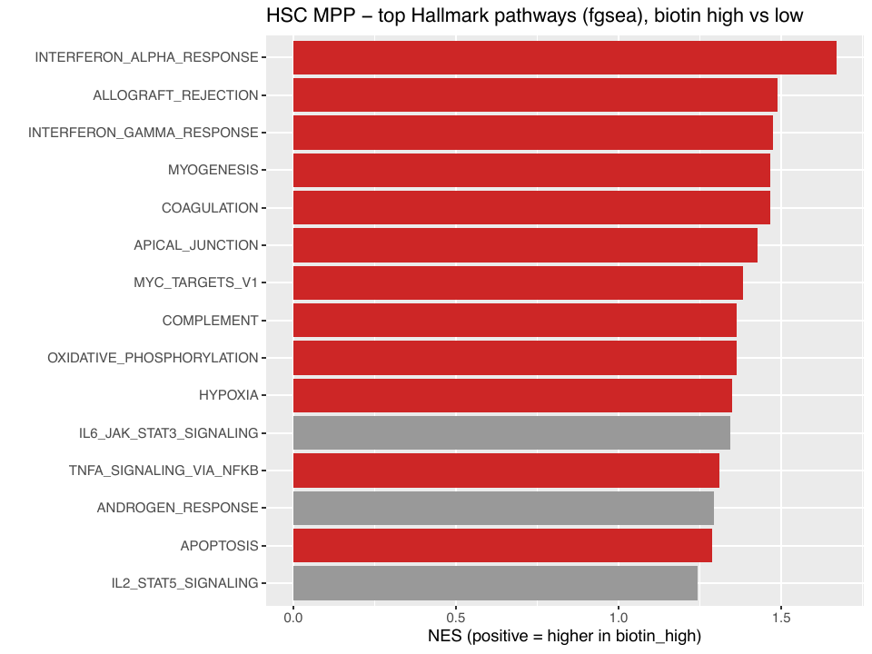

**`5d_findmarkers_top_genes_umap_projected.pdf`**

Top FindMarkers genes on the projected UMAP.

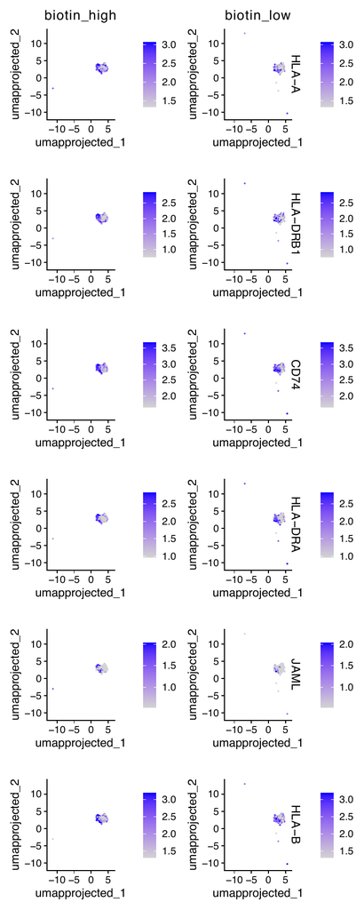

**`6a_findmarkers_top_genes_violin.pdf`**

The same genes as violins by group.

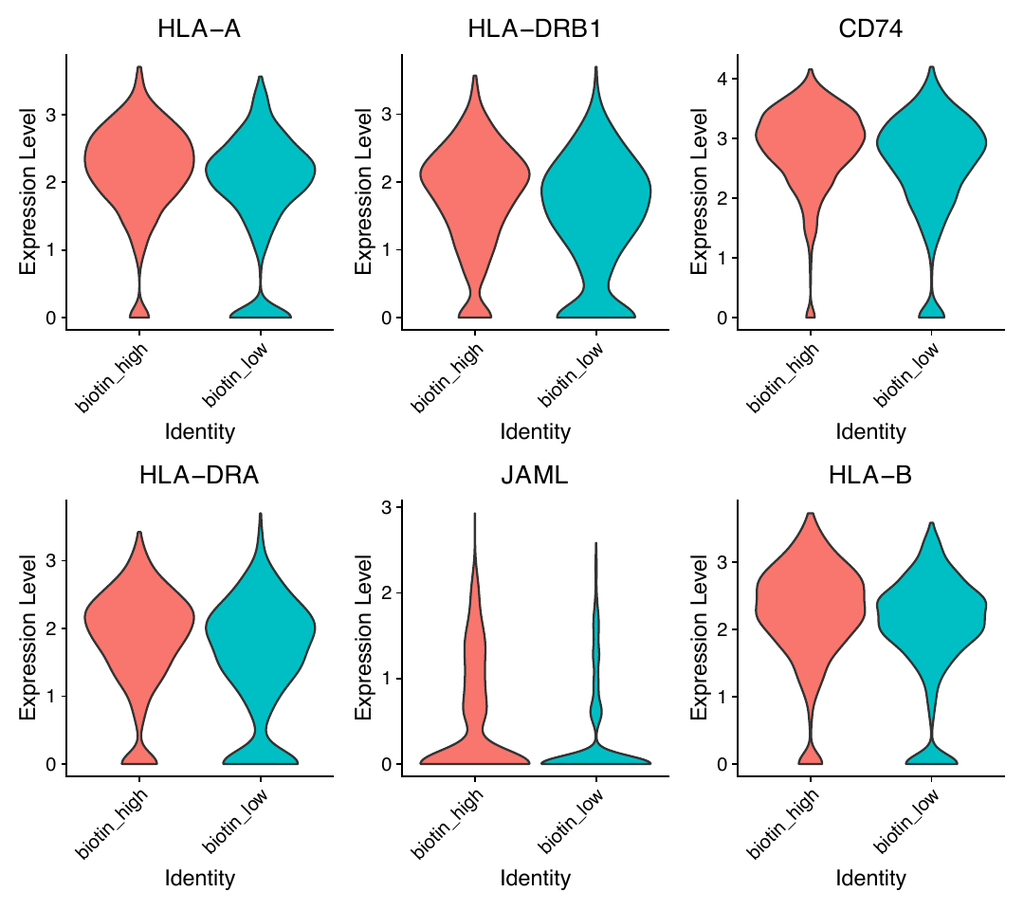

## Surface protein

**`5f_cite_dsb_top_proteins_umap_projected.pdf`**

Top differential CITE_DSB proteins on the projected UMAP.

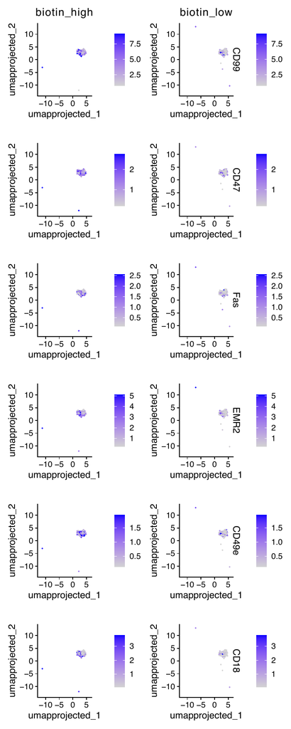

**`6c_cite_dsb_top_proteins_violin.pdf`**

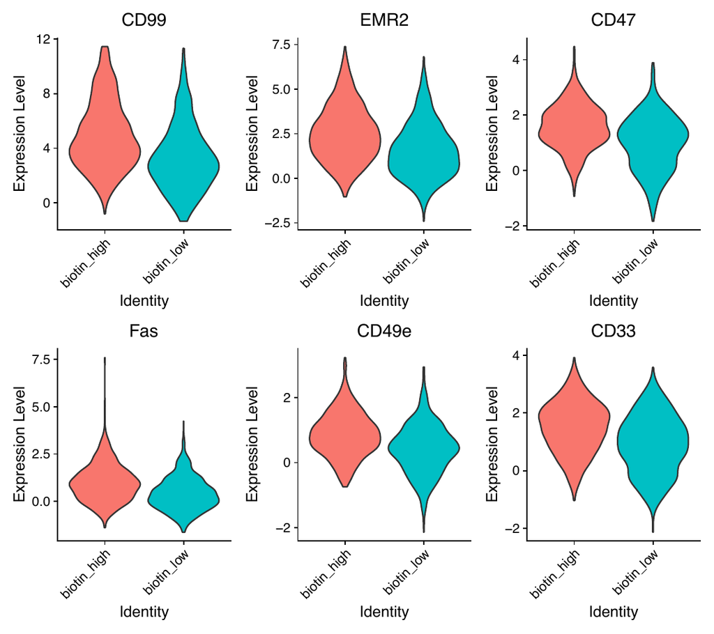

**`3b_glyco_residual_vs_protein_summary.pdf`**

Glycosylation against total surface protein, as residuals. This is the control that matters: without adjusting for surface load, any cell carrying more protein of any kind would appear more glycosylated.

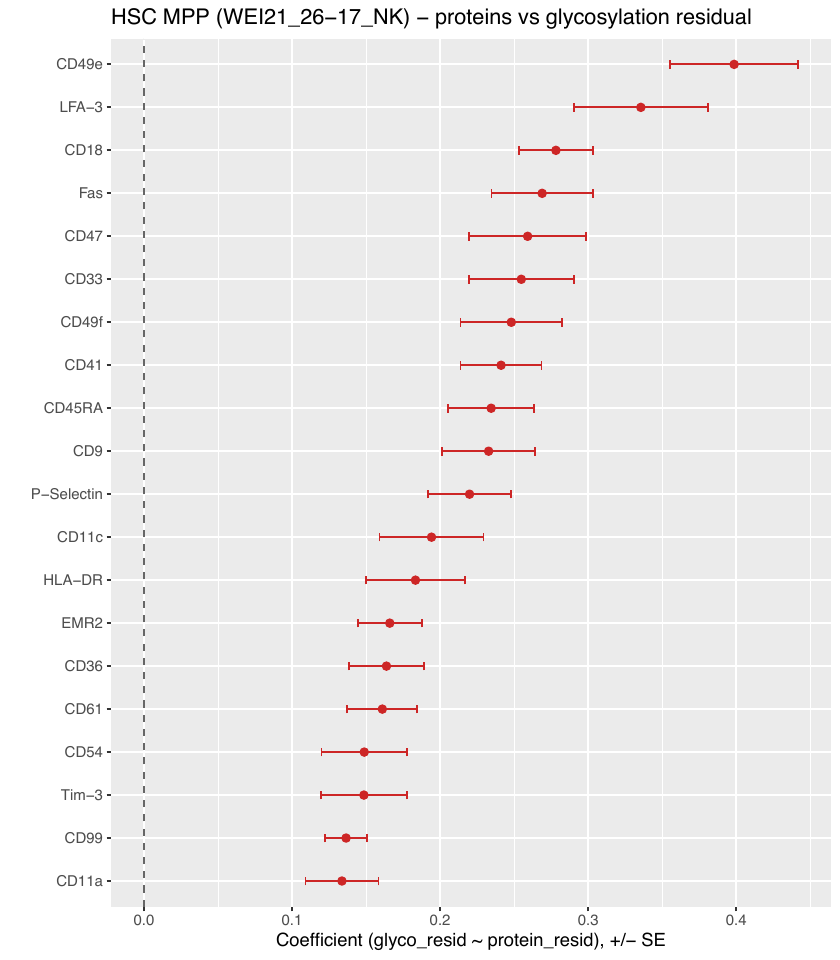

**`3b_glyco_residual_vs_protein_top_scatter.pdf`**

The individual proteins behind that summary.

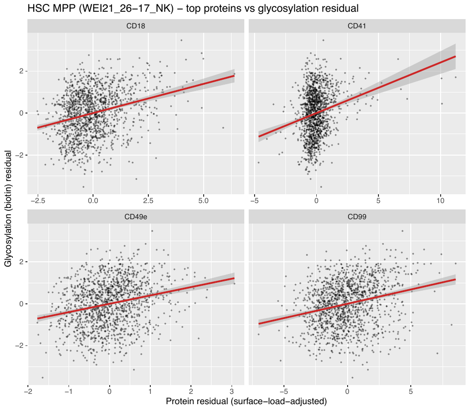

## Cell cycle

**`4_cell_cycle_phase_proportions_biotin_high_vs_low.pdf`**

Cell-cycle phase proportions in the two groups, from Seurat CellCycleScoring.

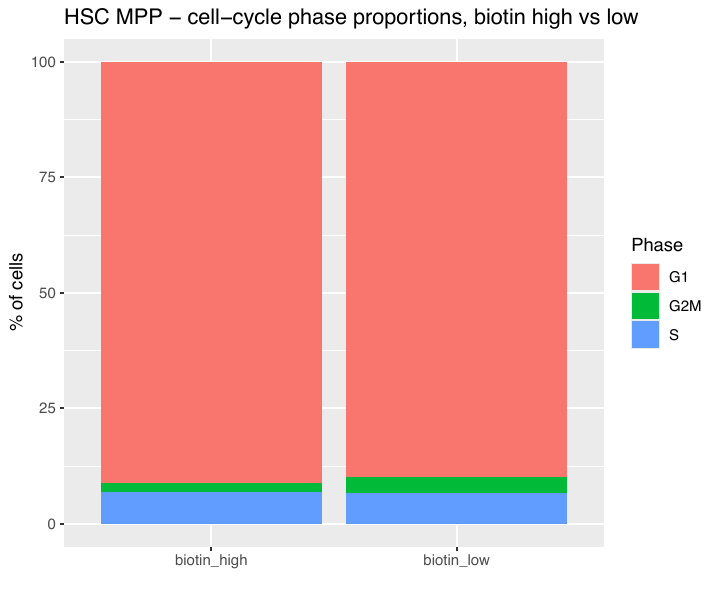

**`5c_cell_cycle_phase_umap_projected.pdf`**

Phase on the projected UMAP, to check the split is not simply tracking proliferation.

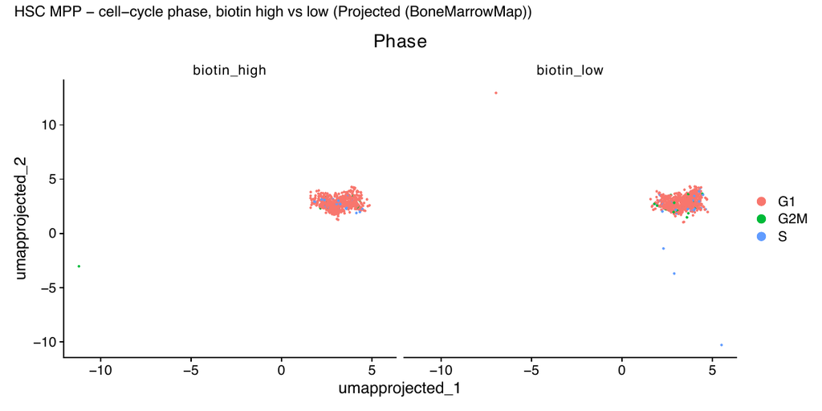

1_findmarkers_biotin_high_vs_low.csv

| gene | p_val | avg_log2FC | pct.1 | pct.2 | p_val_adj |
| --- | --- | --- | --- | --- | --- |
| HLA-A | 0.0000000 | 0.3779058 | 0.958 | 0.853 | 0.0000000 |
| HLA-DRB1 | 0.0000000 | 0.4008393 | 0.918 | 0.813 | 0.0000004 |
| CD74 | 0.0000000 | 0.3065561 | 0.981 | 0.936 | 0.0000004 |
| HLA-DRA | 0.0000000 | 0.3568816 | 0.915 | 0.812 | 0.0000014 |
| JAML | 0.0000000 | 0.7298979 | 0.421 | 0.264 | 0.0000218 |
| HLA-B | 0.0000000 | 0.3602259 | 0.950 | 0.889 | 0.0000225 |
| ALOX5 | 0.0000000 | 0.8080985 | 0.387 | 0.238 | 0.0000264 |
| CKLF | 0.0000000 | 0.4570531 | 0.746 | 0.569 | 0.0000264 |
| B2M | 0.0000000 | 0.2477479 | 0.980 | 0.940 | 0.0001586 |
| ITGB2 | 0.0000000 | 0.3951703 | 0.640 | 0.493 | 0.0003112 |
| GPX1 | 0.0000000 | 0.3368304 | 0.931 | 0.863 | 0.0006495 |
| CTSD | 0.0000000 | 0.3665001 | 0.740 | 0.596 | 0.0007168 |
| GLIPR2 | 0.0000000 | 0.4226815 | 0.462 | 0.320 | 0.0010304 |
| HLA-DMA | 0.0000000 | 0.3677610 | 0.711 | 0.571 | 0.0012998 |
| CD36 | 0.0000001 | 0.5715461 | 0.420 | 0.282 | 0.0017373 |

1b_fgsea_hallmark_biotin_high_vs_low.csv

| pathway | pval | padj | log2err | ES | NES | size | leadingEdge |
| --- | --- | --- | --- | --- | --- | --- | --- |
| HALLMARK_INTERFERON_ALPHA_RESPONSE | 0.0000003 | 0.0000175 | 0.6749629 | 0.7067293 | 1.669594 | 48 | CD74;B2M;HLA-C;PSMB8;IFITM3;SAMD9L;UBA7;IFI30;LGALS3BP;PSMB9;PLSCR1;NUB1;GBP4;NCOA7;PSMA3;CD47;DDX60;PSME1;RIPK2;PSME2;IFI44;TXNIP;MOV10;IRF7;CNP;BST2;CASP8;CASP1;GBP2 |
| HALLMARK_INTERFERON_GAMMA_RESPONSE | 0.0000044 | 0.0001097 | 0.6105269 | 0.6025433 | 1.474864 | 94 | HLA-A;HLA-DRB1;CD74;HLA-B;B2M;HLA-DMA;HLA-DQA1;PSMB8;TNFAIP2;IFITM3;SAMD9L;MARCHF1;IFI30;PTPN1;LGALS3BP;PSMB9;PLSCR1;GBP4;PFKP;PSMA3;CASP4;DDX60;PSME1;PSMA2;RIPK2;PSME2;IFI44;TXNIP;BTG1;SAMHD1;PIM1;SE… |
| HALLMARK_ALLOGRAFT_REJECTION | 0.0000581 | 0.0009683 | 0.5573322 | 0.6189510 | 1.487961 | 63 | HLA-A;CD74;HLA-DRA;B2M;ITGB2;HLA-DMA;HLA-DQA1;GCNT1;HLA-DMB;TIMP1;HLA-E;CTSS;EIF3D;LY86;LTB;STAB1;IL2RA;CD47;NLRP3;RIPK2;HCLS1;IL27RA;IRF7;SRGN |
| HALLMARK_OXIDATIVE_PHOSPHORYLATION | 0.0002711 | 0.0033892 | 0.4984931 | 0.5540784 | 1.361317 | 100 | ATP1B1;SURF1;COX6A1;MRPL15;ATP6V1E1;LDHA;NDUFC1;NDUFS3;COX7B;NDUFB1;ATP5PB;ATP5F1B;NDUFB7;MRPL34;SLC25A5;PDHB;ATP6V0B;ATP5ME;COX6B1;COX4I1;COX6C;GLUD1;NDUFA1;ATP6V0C;NDUFA2;NDUFB8;NDUFV1;ATP5MG;NDUFA3… |
| HALLMARK_MYC_TARGETS_V1 | 0.0005450 | 0.0054496 | 0.4772708 | 0.5661953 | 1.383107 | 88 | LDHA;DUT;PCBP1;DEK;PSMA1;HSPE1;EIF4G2;H2AZ1;RAN;USP1;MCM4;EIF2S2;EIF3D;PRPF31;PSMA7;U2AF1;PSMA2;PPM1G;PSMD8;CCT5;SNRPB2;SNRPG;AIMP2;PGK1;SET;AP3S1;SLC25A3;VDAC3;PSMA4;EIF2S1;SSBP1;PSMD7;CNBP;VBP1;CBX3… |
| HALLMARK_APICAL_JUNCTION | 0.0012610 | 0.0105080 | 0.4550599 | 0.6034140 | 1.427791 | 50 | ACTB;CD99;CAP1;GNAI2;VCL;GNAI1;ACTG1;PFN1;RAC2;MYL12B;YWHAH;HADH;LIMA1;CTNND1;MDK;RSU1;DHX16;JAM3;MSN;ICAM2;EPB41L2;RHOF;ADAM15;GAMT |
| HALLMARK_COMPLEMENT | 0.0020534 | 0.0146672 | 0.4317077 | 0.5650914 | 1.361355 | 66 | CTSD;CD36;CASP10;DPP4;TIMP1;PSMB9;CTSC;GNAI2;RHOG;PLSCR1;CBLB;PIK3CG;PFN1;CTSS;DUSP6;CASP4;RABIF;CALM1;PIM1;DOCK10;SERPING1;IRF7;GNB2;CSRP1;CASP1;GCA |
| HALLMARK_COAGULATION | 0.0033787 | 0.0211169 | 0.4317077 | 0.6476230 | 1.464987 | 26 | DPP4;TIMP1;DUSP6;PEF1;CFD;RABIF;SERPING1;GSN;GNB2;CSRP1;ANXA1;MSRB2;WDR1;RAC1;CAPN2;LAMP2;ISCU;USP11;SERPINA1 |
| HALLMARK_MYOGENESIS | 0.0038528 | 0.0214042 | 0.4317077 | 0.6408595 | 1.465071 | 29 | CD36;PTP4A3;SVIL;PDLIM7;MEF2C;LSP1;APP;SPTAN1;CFD;PDE4DIP;GSN;FLII |
| HALLMARK_TNFA_SIGNALING_VIA_NFKB | 0.0047220 | 0.0221396 | 0.4070179 | 0.5405460 | 1.308564 | 70 | DUSP1;TNFAIP2;TSC22D1;ZFP36;MCL1;SAT1;KLF2;JUNB;EGR1;CD83;BCL2A1;EIF1;MAP3K8;NINJ1;LITAF;RIPK2;TNIP1;KLF6;FOS;BTG1;GPR183;JUN;PHLDA1;BIRC2;SLC2A3;BTG3;RELA;GADD45B;RNF19B;FOSL2;FOSB;KYNU;SOD2;CEBPB |
| HALLMARK_HYPOXIA | 0.0048707 | 0.0221396 | 0.4070179 | 0.5625511 | 1.348408 | 61 | DUSP1;SLC2A5;ZFP36;GAPDH;LDHA;DDIT4;PFKP;TPST2;S100A4;SIAH2;HEXA;RRAGD;KLF6;FOS;BTG1;PIM1;SAP30;PGK1;JUN;NAGK;HDLBP;PRDX5;SLC2A3;ANKZF1;FAM162A;PGM2;PGM1;FOSL2 |
| HALLMARK_APOPTOSIS | 0.0114335 | 0.0476398 | 0.3807304 | 0.5317281 | 1.288523 | 71 | GPX1;IFITM3;TIMP1;MCL1;PMAIP1;SAT1;PAK1;APP;SLC20A1;SPTAN1;CASP4;TXNIP;CYLD;GSN;JUN;BCAP31;ANXA1;CASP8;IGF2R;CASP1;PLCB2;VDAC2;TSPO;GPX4;IFNGR1;BTG3;RELA;GADD45B;DNAJA1;EMP1;BAX;BCL10;SOD2;XIAP;CCNA1;… |
| HALLMARK_IL2_STAT5_SIGNALING | 0.0249750 | 0.0938023 | 0.2878571 | 0.5109612 | 1.243654 | 78 | GLIPR2;IFITM3;CTSZ;IL3RA;CYFIP1;GSTO1;PLSCR1;GBP4;CD83;SOCS2;MAP3K8;TNFRSF18;LTB;IL2RA;RRAGD;KLF6;LRRC8C;TNFRSF1B;PIM1;IGF2R;PHLDA1;SLC2A3;GPX4;IFNGR1;GADD45B;ITGAE;AHCY;GABARAPL1;EMP1 |
| HALLMARK_ANDROGEN_RESPONSE | 0.0280280 | 0.0938023 | 0.2712886 | 0.5537309 | 1.293734 | 40 | B2M;TSC22D1;HERC3;SAT1;DBI;MYL12A;NGLY1;RAB4A;GUCY1A1;IDI1;TMEM50A |
| HALLMARK_IL6_JAK_STAT3_SIGNALING | 0.0281407 | 0.0938023 | 0.2712886 | 0.5855548 | 1.343808 | 30 | CD36;IL3RA;PTPN1;IL10RB;MAP3K8;LTB;IL2RA;TNFRSF1B;PIM1;JUN;IFNAR1;STAM2;IFNGR1 |

2_pseudobulk_deseq2_biotin_high_vs_low.csv

| gene | logFC | logCPM | PValue | FDR | n_high | n_low |
| --- | --- | --- | --- | --- | --- | --- |
| ENSG00000291215 | -0.0226942 | 4.084848 | 0.9811972 | 0.999988 | 684 | 685 |
| LINC01409 | 0.0235046 | 5.696121 | 0.9783209 | 0.999988 | 684 | 685 |
| ENSG00000290784 | 1.0191247 | 3.425298 | 0.3443618 | 0.999988 | 684 | 685 |
| LINC00115 | 0.2117707 | 3.513530 | 0.8378416 | 0.999988 | 684 | 685 |
| LINC01128 | 0.5585734 | 4.977871 | 0.5348130 | 0.999988 | 684 | 685 |
| NOC2L | 0.0175761 | 7.175743 | 0.9831810 | 0.999988 | 684 | 685 |
| ISG15 | 0.0508354 | 7.213841 | 0.9513551 | 0.999988 | 684 | 685 |
| C1orf159 | -0.0603082 | 5.685074 | 0.9444326 | 0.999988 | 684 | 685 |
| TTLL10 | 0.4212241 | 4.959651 | 0.6395614 | 0.999988 | 684 | 685 |
| TNFRSF18 | 0.4127231 | 6.858750 | 0.6226507 | 0.999988 | 684 | 685 |
| TNFRSF4 | 0.1324141 | 8.644643 | 0.8721051 | 0.999988 | 684 | 685 |
| SDF4 | 0.0094957 | 8.621808 | 0.9907897 | 0.999988 | 684 | 685 |
| B3GALT6 | 0.0826427 | 6.351152 | 0.9223013 | 0.999988 | 684 | 685 |
| UBE2J2 | 0.2865393 | 7.813023 | 0.7291838 | 0.999988 | 684 | 685 |
| ACAP3 | 0.1996985 | 6.710629 | 0.8122232 | 0.999988 | 684 | 685 |

2_pseudobulk_edgeR_biotin_high_vs_low.csv

| gene | logFC | logCPM | PValue | FDR | n_high | n_low |
| --- | --- | --- | --- | --- | --- | --- |
| NFIA-AS2 | -7.436254 | 0.9574418 | 0.0009007 | 1 | 684 | 685 |
| ZNF502 | -3.263622 | 1.4177032 | 0.0090302 | 1 | 684 | 685 |
| ENSG00000223576 | 3.182053 | 1.1179739 | 0.0125866 | 1 | 684 | 685 |
| AKAP12 | 3.735561 | 0.7733070 | 0.0128214 | 1 | 684 | 685 |
| PLK2 | -2.414068 | 2.5525250 | 0.0148245 | 1 | 684 | 685 |
| CCDC80 | 3.648802 | 0.7073528 | 0.0162256 | 1 | 684 | 685 |
| RCAN2 | 3.045422 | 1.0131098 | 0.0183347 | 1 | 684 | 685 |
| BFSP2 | -2.551518 | 1.4991026 | 0.0298844 | 1 | 684 | 685 |
| HTR7 | 2.725889 | 0.7765933 | 0.0417569 | 1 | 684 | 685 |
| ENSG00000260919 | 2.725889 | 0.7765933 | 0.0417569 | 1 | 684 | 685 |
| HRH1 | 2.148100 | 1.4417468 | 0.0513877 | 1 | 684 | 685 |
| CDKN1A | -1.856315 | 2.7518162 | 0.0562336 | 1 | 684 | 685 |
| ENSG00000288942 | 2.155500 | 1.1735359 | 0.0578481 | 1 | 684 | 685 |
| HDAC2-AS2 | -1.961936 | 1.4936341 | 0.0601929 | 1 | 684 | 685 |
| PEAK3 | 2.534953 | 0.6415567 | 0.0656334 | 1 | 684 | 685 |

3_cite_dsb_wilcoxon_biotin_high_vs_low.csv

| protein | n_high | n_low | mean_high | mean_low | mean_diff | pvalue | FDR |
| --- | --- | --- | --- | --- | --- | --- | --- |
| biotin | 684 | 685 | 2.0200481 | 0.2860675 | 1.7339806 | 0 | 0 |
| CD99 | 684 | 685 | 4.9607297 | 3.3117641 | 1.6489655 | 0 | 0 |
| EMR2 | 684 | 685 | 2.5437241 | 1.6374486 | 0.9062755 | 0 | 0 |
| CD47 | 684 | 685 | 1.5874614 | 1.0654556 | 0.5220058 | 0 | 0 |
| Fas | 684 | 685 | 1.0367756 | 0.5651041 | 0.4716714 | 0 | 0 |
| CD49e | 684 | 685 | 0.8926937 | 0.5476195 | 0.3450742 | 0 | 0 |
| CD33 | 684 | 685 | 1.5170085 | 1.0087878 | 0.5082207 | 0 | 0 |
| CD45RA | 684 | 685 | 1.8190673 | 1.2115961 | 0.6074712 | 0 | 0 |
| CD18 | 684 | 685 | 1.0486318 | 0.4241690 | 0.6244628 | 0 | 0 |
| LFA-3 | 684 | 685 | 0.5428249 | 0.2970006 | 0.2458244 | 0 | 0 |
| HLA-ABC | 684 | 685 | 1.9652520 | 1.3803815 | 0.5848705 | 0 | 0 |
| CD54 | 684 | 685 | 1.2431237 | 0.7741792 | 0.4689444 | 0 | 0 |
| CD49f | 684 | 685 | 0.5854978 | 0.2894551 | 0.2960426 | 0 | 0 |
| CD123 | 684 | 685 | 4.2958018 | 3.2325294 | 1.0632725 | 0 | 0 |
| HLA-DR | 684 | 685 | 1.2534349 | 0.8768929 | 0.3765420 | 0 | 0 |

3b_glyco_residual_vs_glycosyltransferase_RNA.csv

| gene | coef | pvalue | FDR |
| --- | --- | --- | --- |
| ST6GAL1 | 0.0272304 | 0.7139698 | 0.7356198 |
| FUT8 | 0.0236438 | 0.7356198 | 0.7356198 |
| MGAT5 | 0.0352814 | 0.4649772 | 0.7356198 |
| B4GALT1 | -0.0213735 | 0.6943826 | 0.7356198 |

3b_glyco_residual_vs_protein_residual.csv

| protein | coef | se | pvalue | r_squared | FDR |
| --- | --- | --- | --- | --- | --- |
| CD18 | 0.2782090 | 0.0249493 | 0 | 0.0833771 | 0 |
| CD99 | 0.1365042 | 0.0140432 | 0 | 0.0646498 | 0 |
| CD49e | 0.3985519 | 0.0432372 | 0 | 0.0585191 | 0 |
| CD41 | 0.2411699 | 0.0273375 | 0 | 0.0538660 | 0 |
| CD45RA | 0.2344736 | 0.0291435 | 0 | 0.0452108 | 0 |
| Fas | 0.2689074 | 0.0342309 | 0 | 0.0431940 | 0 |
| P-Selectin | 0.2198772 | 0.0279963 | 0 | 0.0431740 | 0 |
| EMR2 | 0.1660015 | 0.0216827 | 0 | 0.0411146 | 0 |
| LFA-3 | 0.3355625 | 0.0452997 | 0 | 0.0385919 | 0 |
| CD9 | 0.2327471 | 0.0314510 | 0 | 0.0385188 | 0 |
| CD49f | 0.2480743 | 0.0342590 | 0 | 0.0369402 | 0 |
| CD33 | 0.2548260 | 0.0354929 | 0 | 0.0363380 | 0 |
| CD61 | 0.1609890 | 0.0236225 | 0 | 0.0328597 | 0 |
| CD47 | 0.2591014 | 0.0394148 | 0 | 0.0306434 | 0 |
| CD36 | 0.1637732 | 0.0253101 | 0 | 0.0297185 | 0 |

4_cell_cycle_phase_proportions_biotin_high_vs_low.csv

| biotin_group | Phase | n | pct |
| --- | --- | --- | --- |
| biotin_high | G1 | 624 | 91.228070 |
| biotin_high | G2M | 13 | 1.900585 |
| biotin_high | S | 47 | 6.871345 |
| biotin_low | G1 | 616 | 89.927007 |
| biotin_low | G2M | 23 | 3.357664 |
| biotin_low | S | 46 | 6.715329 |

# 3b. The same split in monocytes

Monocytes carry the most biotin, so they are the obvious population to split. This arm had never been run - the report script existed but nothing wrote the object it needs. Step 02a is step 02 with the population taken as an argument; run as `Rscript 02a.biotin_split_analysis_runnable.R "Monocyte"` it produced everything below.

**The population is small.** 160 monocytes pass QC in this sample, splitting 80 high and 80 low at the median. That is a tenth of the HSC/MPP compartment, and it is why the pseudobulk contrast here is thinner - treat the gene-level results as indicative only.

**`5a_biotin_group_umap_projected.pdf`**

Biotin-high and biotin-low monocytes on the projected UMAP.

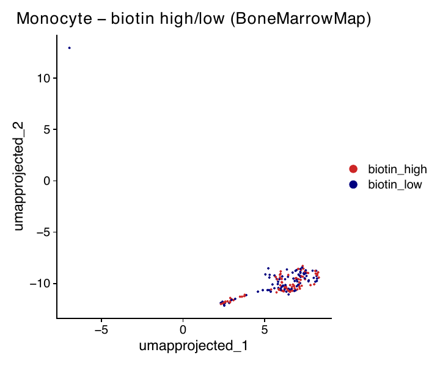

**`5b_biotin_value_umap_projected.pdf`**

Biotin as a continuous value across the same cells.

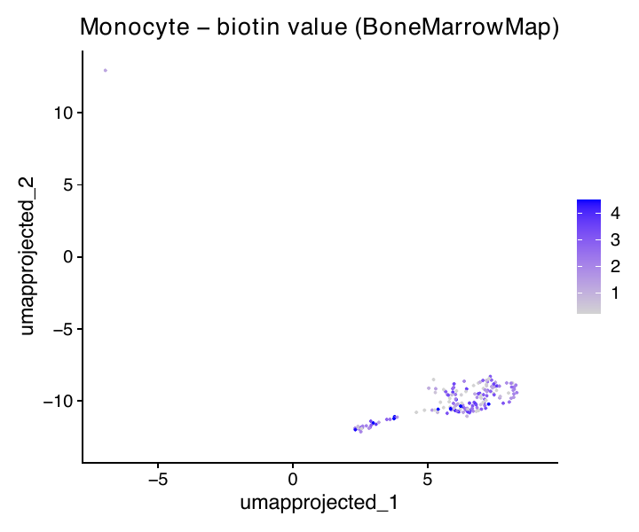

**`2_pseudobulk_deseq2_volcano_biotin_high_vs_low.pdf`**

Pseudobulk DESeq2, biotin-high against biotin-low monocytes.

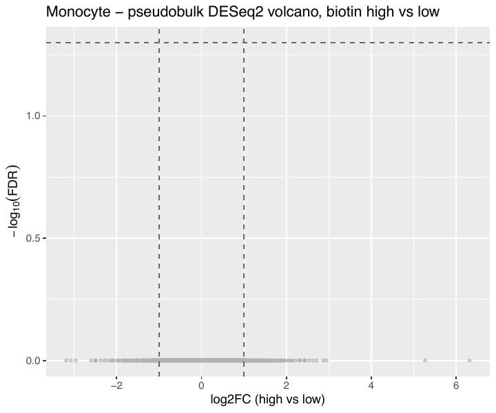

**`1b_fgsea_hallmark_kegg_biotin_high_vs_low.pdf`**

fgsea over Hallmark and KEGG on the FindMarkers ranking.

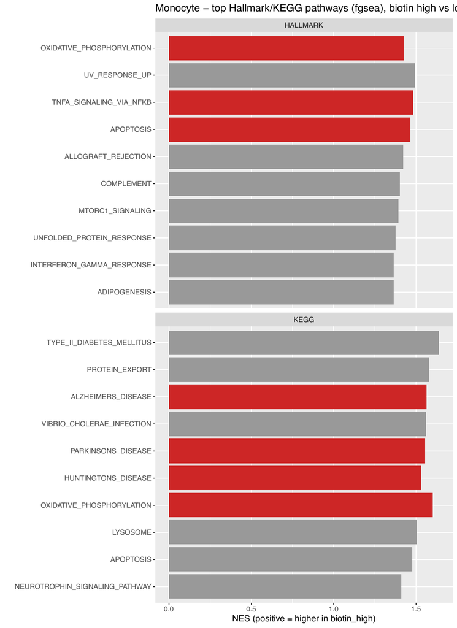

**`3b_glyco_by_fine_celltype_violin.pdf`**

Glycosylation by fine cell type within the monocyte compartment.

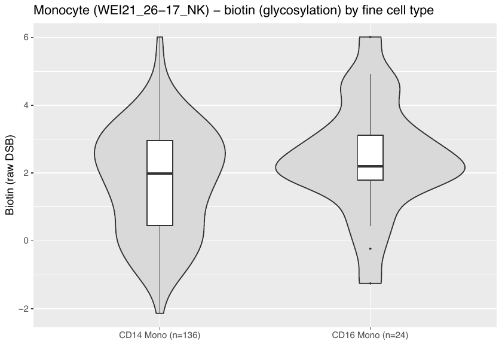

**`3c_glyco_residual_vs_protein_summary.pdf`**

Glycosylation against total surface load, as residuals.

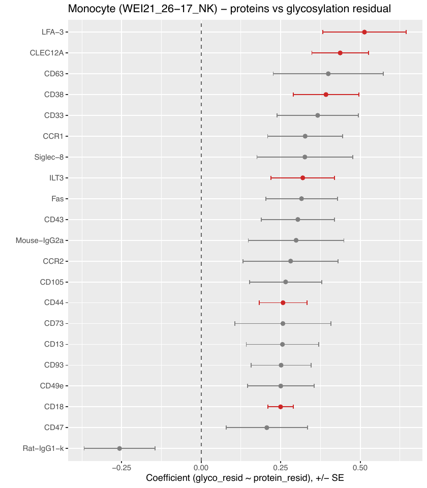

**`4_cell_cycle_phase_proportions_biotin_high_vs_low.pdf`**

Cell-cycle phase by group. Both are overwhelmingly G1 - 92.5% of biotin-high and 87.5% of biotin-low - so the split is not separating cycling from non-cycling cells.

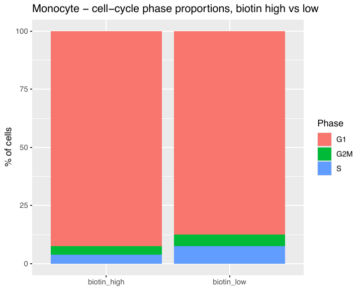

**`6c_cite_dsb_top_proteins_violin.pdf`**

Top differential CITE_DSB proteins between the groups.

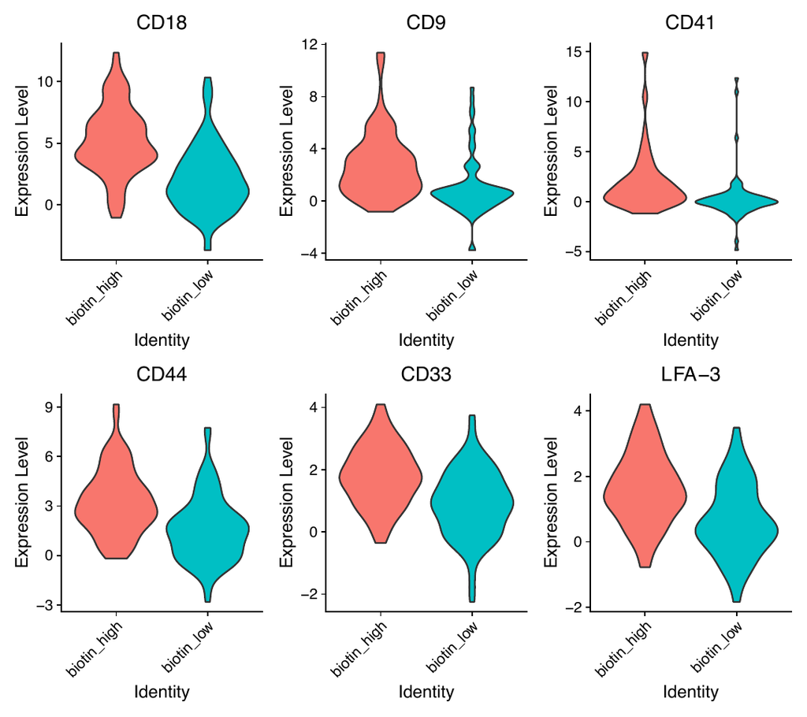

3b_fine_celltype_counts.csv

| predicted_CellType | n_cells |
| --- | --- |
| CD14 Mono | 136 |
| CD16 Mono | 24 |

4_cell_cycle_phase_proportions_biotin_high_vs_low.csv

| biotin_group | Phase | n | pct |
| --- | --- | --- | --- |
| biotin_high | G1 | 74 | 92.50 |
| biotin_high | G2M | 3 | 3.75 |
| biotin_high | S | 3 | 3.75 |
| biotin_low | G1 | 70 | 87.50 |
| biotin_low | G2M | 4 | 5.00 |
| biotin_low | S | 6 | 7.50 |

3_cite_dsb_wilcoxon_biotin_high_vs_low.csv

| protein | n_high | n_low | mean_high | mean_low | mean_diff | pvalue | FDR |
| --- | --- | --- | --- | --- | --- | --- | --- |
| biotin | 80 | 80 | 3.168332 | 0.7621464 | 2.4061859 | 0.0000000 | 0.0000000 |
| CD18 | 80 | 80 | 5.207457 | 2.3071295 | 2.9003277 | 0.0000000 | 0.0000000 |
| CD9 | 80 | 80 | 2.811949 | 1.2337203 | 1.5782291 | 0.0000001 | 0.0000044 |
| CD41 | 80 | 80 | 2.029657 | 0.6569892 | 1.3726678 | 0.0000001 | 0.0000051 |
| CD44 | 80 | 80 | 3.253246 | 1.7457401 | 1.5075062 | 0.0000002 | 0.0000073 |
| CD33 | 80 | 80 | 1.803108 | 1.0138290 | 0.7892788 | 0.0000004 | 0.0000122 |
| LFA-3 | 80 | 80 | 1.645868 | 0.8188754 | 0.8269930 | 0.0000005 | 0.0000122 |
| CLEC12A | 80 | 80 | 1.986972 | 1.0879175 | 0.8990546 | 0.0000005 | 0.0000125 |
| CD31 | 80 | 80 | 2.637690 | 1.4012343 | 1.2364553 | 0.0000007 | 0.0000153 |
| CD45 | 80 | 80 | 2.326624 | 1.3186931 | 1.0079308 | 0.0000016 | 0.0000299 |
| CD11b | 80 | 80 | 3.052445 | 1.6126008 | 1.4398442 | 0.0000020 | 0.0000310 |
| CD54 | 80 | 80 | 3.043211 | 1.7543823 | 1.2888290 | 0.0000020 | 0.0000310 |
| P-Selectin | 80 | 80 | 1.642489 | 0.6762009 | 0.9662876 | 0.0000025 | 0.0000362 |
| EMR2 | 80 | 80 | 3.654302 | 2.2224542 | 1.4318474 | 0.0000028 | 0.0000371 |
| CD11a | 80 | 80 | 4.613571 | 2.8927332 | 1.7208373 | 0.0000030 | 0.0000371 |

Two differences from the HSC/MPP outputs are worth noting rather than glossing. This run writes its UMAPs into a `umaps/` subdirectory while the HSC/MPP figures sit flat, and it produces no edgeR volcano where HSC/MPP has one - both because the HSC/MPP outputs came from an earlier version of the analysis script than the one frozen here as step 02.